# Erementarz

6. kwietnia 2019

## Zaczynamy

[figure not shown]

## Wczytanie danych

Do **R** można wczytywać dane na wiele sposobów, my skorzystamy z funkcji **read.csv**.

Najpierw warto sprawdzić jaki katalog jest ,,domyślny'' i w razie potrzeby zmienić go na inny za pomocą funkcji **setwd()**.

```r
data <- read.csv("dane/german_credit_data.csv",
                       encoding = "UTF-8")
```

Do zmiennej *data* przypisaliśmy wynik funkcji *read.csv*.

## Obiekty

```r
# wymiary tabeli
dim(data)
```

```
## [1] 1000   11
```

```r
# pierwsze wiersze z tabeli
##data[1:4,1:11]
head(data)
```

```
##   X Age    Sex Job Housing Saving.accounts Checking.account Credit.amount
## 1 0  67   male   2     own            <NA>           little          1169
## 2 1  22 female   2     own          little         moderate          5951
## 3 2  49   male   1     own          little             <NA>          2096
## 4 3  45   male   2    free          little           little          7882
## 5 4  53   male   2    free          little           little          4870
## 6 5  35   male   1    free            <NA>             <NA>          9055
##   Duration             Purpose Risk
## 1        6            radio/TV good
## 2       48            radio/TV  bad
## 3       12           education good
## 4       42 furniture/equipment good
## 5       24                 car  bad
## 6       36           education good
```

## Interfejs w RStudio

[figure not shown]

## Przeglądanie danych

Przy niedużych zbiorach danych możemy w łatwy sposób poznać strukturę:

[figure not shown]

## Co to za dane?

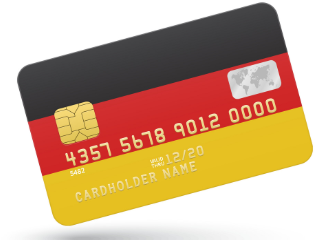

**German credit data** dotyczą klientów banku i oceny ich zdolności kredytowej. Występujące zmienne:

- X - liczba porządkowa,
- Age - wiek w latach,
- Sex - płeć,
- Job - rodzaj pracy, gdzie wyższa liczba oznacza wyższy stopień wykwalifikowania,
- Housing - mieszkanie własne, czynszowe, bądź bezczynszowe,
- Saving accounts - im więcej, tym wyższa wartość konta oszczędnościowego/obligacji,
- Credit amount - kwota kredytu w markach niemieckich,
- Duration - czas trwania (w miesiącach),
- Purpos - przeznaczenie kredytu,
- Risk - klient dobry/zły.

[figure not shown]

## Zapoznajemy się z danymi…

Jakie pytania warto sobie zadać?

```r
levels(data$Purpose)
```

```
## [1] "business"            "car"                 "domestic appliances"
## [4] "education"           "furniture/equipment" "radio/TV"
## [7] "repairs"             "vacation/others"
```

## Czy typy się zgadzają?

```r
sapply(data, class)
```

```
##                X              Age              Sex              Job
##        "integer"        "integer"         "factor"        "integer"
##          Housing  Saving.accounts Checking.account    Credit.amount
##         "factor"         "factor"         "factor"        "integer"
##         Duration          Purpose             Risk
##        "integer"         "factor"         "factor"
```

## Przekodowane?

```r
data2<-data
data2$Job <- factor(x = as.character(data$Job),
                   labels =
                     c('unskilled and non-resident',
                       'unskilled and resident',
                       'skilled','highly skilled'))
head(data2$Job)
```

```
## [1] skilled                skilled                unskilled and resident
## [4] skilled                skilled                unskilled and resident
## 4 Levels: unskilled and non-resident unskilled and resident ... highly skilled
```

## Ćwiczenie 1

Zapropononuj inne modyfikacje. Można np. użyć funkcji **as.numeric**, żeby przekonwertować tekst na wartości liczbowe.

[figure not shown]

## Przykład rozwiązania

```r
data2$Risk<-as.numeric(x=data$Risk,labels=c(1,2))
head(data2$Risk)#1-bad, 2-good
```

```
## [1] 2 1 2 2 1 2
```

[figure not shown]

## Obiekty

```r
# podsumowanie tabeli
summary(data2)
```

```
##        X              Age            Sex
##  Min.   :  0.0   Min.   :19.00   female:310
##  1st Qu.:249.8   1st Qu.:27.00   male  :690
##  Median :499.5   Median :33.00
##  Mean   :499.5   Mean   :35.55
##  3rd Qu.:749.2   3rd Qu.:42.00
##  Max.   :999.0   Max.   :75.00
##
##                          Job      Housing      Saving.accounts
##  unskilled and non-resident: 22   free:108   little    :603
##  unskilled and resident    :200   own :713   moderate  :103
##  skilled                   :630   rent:179   quite rich: 63
##  highly skilled            :148              rich      : 48
##                                              NA's      :183
##
##
##  Checking.account Credit.amount      Duration                   Purpose
##  little  :274     Min.   :  250   Min.   : 4.0   car                :337
##  moderate:269     1st Qu.: 1366   1st Qu.:12.0   radio/TV           :280
##  rich    : 63     Median : 2320   Median :18.0   furniture/equipment:181
##  NA's    :394     Mean   : 3271   Mean   :20.9   business           : 97
##                   3rd Qu.: 3972   3rd Qu.:24.0   education          : 59
##                   Max.   :18424   Max.   :72.0   repairs            : 22
##                                                  (Other)            : 24
##       Risk
##  Min.   :1.0
##  1st Qu.:1.0
##  Median :2.0
##  Mean   :1.7
##  3rd Qu.:2.0
##  Max.   :2.0
##
```

Zwykle można zrobić to też inaczej:

```r
# podsumowanie tabeli
library(funModeling)
funModeling::df_status(data2)
```

```
##            variable q_zeros p_zeros q_na p_na q_inf p_inf    type unique
## 1                 X       1     0.1    0  0.0     0     0 integer   1000
## 2               Age       0     0.0    0  0.0     0     0 integer     53
## 3               Sex       0     0.0    0  0.0     0     0  factor      2
## 4               Job       0     0.0    0  0.0     0     0  factor      4
## 5           Housing       0     0.0    0  0.0     0     0  factor      3
## 6   Saving.accounts       0     0.0  183 18.3     0     0  factor      4
## 7  Checking.account       0     0.0  394 39.4     0     0  factor      3
## 8     Credit.amount       0     0.0    0  0.0     0     0 integer    921
## 9          Duration       0     0.0    0  0.0     0     0 integer     33
## 10          Purpose       0     0.0    0  0.0     0     0  factor      8
## 11             Risk       0     0.0    0  0.0     0     0 numeric      2
```

## Podstawowe zależności

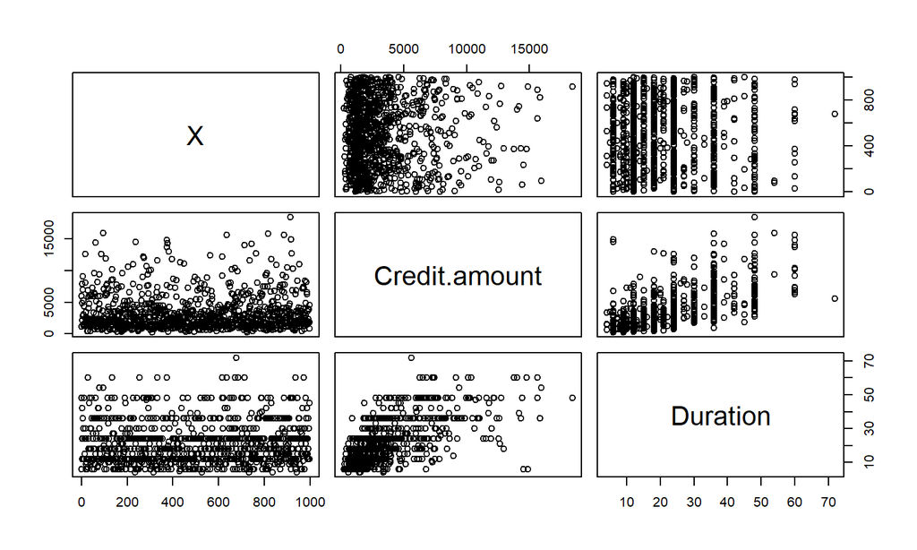

```r
pairs(data[,c(1,8,9)])
```

## Braki w danych, poprawność

Istnieje wiele podejść do tego tematu, np. zastąpienie konkretną wartością, zastąpienie jakąś z agregacji, pominięcie rekordów lub skorzystanie z predykcji. Istnieją pakiety do obróbki brakujących danych, np. **mitools.**

```r
data2<-na.omit(data2)
head(is.na(data2))
```

```
##        X   Age   Sex   Job Housing Saving.accounts Checking.account
## 2  FALSE FALSE FALSE FALSE   FALSE           FALSE            FALSE
## 4  FALSE FALSE FALSE FALSE   FALSE           FALSE            FALSE
## 5  FALSE FALSE FALSE FALSE   FALSE           FALSE            FALSE
## 8  FALSE FALSE FALSE FALSE   FALSE           FALSE            FALSE
## 10 FALSE FALSE FALSE FALSE   FALSE           FALSE            FALSE
## 11 FALSE FALSE FALSE FALSE   FALSE           FALSE            FALSE
##    Credit.amount Duration Purpose  Risk
## 2          FALSE    FALSE   FALSE FALSE
## 4          FALSE    FALSE   FALSE FALSE
## 5          FALSE    FALSE   FALSE FALSE
## 8          FALSE    FALSE   FALSE FALSE
## 10         FALSE    FALSE   FALSE FALSE
## 11         FALSE    FALSE   FALSE FALSE
```

## Przeglądanie większych zbiorów

**SQL**? Warto spróbować!

```r
library(sqldf)
zapytanie1<-"select Age, Sex, Risk
from data2
order by Age desc
limit 5"
sqldf(zapytanie1)
```

```
##   Age    Sex Risk
## 1  75   male    2
## 2  74 female    1
## 3  74   male    2
## 4  70   male    2
## 5  68   male    2
```

## Wczytywanie konkretnych wyników

```r
zapytanie0<-read.csv.sql("dane/german_credit_data.csv",
sql = "select Age, Sex, Risk
from file order by Age desc limit 5")
print(zapytanie0)
```

```
##   Age    Sex Risk
## 1  75   male good
## 2  75 female good
## 3  74 female  bad
## 4  74   male good
## 5  74   male good
```

## Przykładowe agregacje

Średni wiek ,,złych'' mężczyzn…

```r
zapytanie2 = "select avg(Age) as sredni_wiek
from data2 WHERE Sex='male' and Risk=1"
sqldf(zapytanie2)
```

```
##   sredni_wiek
## 1    36.14765
```

*Ćwiczenie 2*: Podaj średnią kwotę kredytu w markach niemieckich dla kobiet, które są ,,dobrymi'' klientami.

## Przykład rozwiązania

```r
zapytanie3 = 'select avg("Credit.amount") as [Kwota kredytu]
from data2 where Sex="female" and Risk=2'
sqldf(zapytanie3)
```

```
##   Kwota kredytu
## 1      2465.826
```

## Grupowanie

Połączenie poprzednich ćwiczeń:

```r
zapytanie4 = 'select Sex,Risk,
avg(Age) as [Wiek],
avg("Credit.amount") as [Kwota kredytu]
from data2 group by Sex,Risk'
sqldf(zapytanie4)
```

```
##      Sex Risk     Wiek Kwota kredytu
## 1 female    1 30.51220      3431.573
## 2 female    2 34.82558      2465.826
## 3   male    1 36.14765      4128.477
## 4   male    2 35.75122      2941.034
```

## Pakiet dplyr

Jeden z popularniejszych pakietów do przetwarzania danych. Kluczowe fragmenty zaimplementowane w **Rcpp**.

```r
library(dplyr)
select(data2,Age,Sex,Risk)
```

```
##      Age    Sex Risk
## 2     22 female    1
## 4     45   male    2
## 5     53   male    1
## 8     35   male    2
## 10    28   male    1
## 11    25 female    1
## 12    24 female    1
## 13    22 female    2
## 14    60   male    1
## 15    28 female    2
## 16    32 female    1
## 19    44 female    1
## 22    44   male    2
## 23    48   male    2
```

[output cut: 508 more lines]

## Konstrukcja chain

```r
data2 %>%
select(Age,Sex,Risk) %>%
arrange(Age) %>%
top_n(5)
```

```
##     Age    Sex Risk
## 1    19 female    2
## 2    20 female    2
## 3    20 female    2
## 4    20   male    2
## 5    20   male    2
## 6    21   male    2
## 7    21   male    2
## 8    21   male    2
## 9    21 female    2
## 10   22 female    2
## 11   22   male    2
## 12   22   male    2
## 13   22   male    2
## 14   22   male    2
```

[output cut: 277 more lines]

## Agregacje nieco inaczej

Średni wiek ,,złych'' mężczyzn…

```r
data2 %>%
  filter (Sex=='male', Risk==1) %>%
  summarise(sredni_wiek=mean(Age))
```

```
##   sredni_wiek
## 1    36.14765
```

*Ćwiczenie 3*: Podaj średnią kwotę kredytu w markach niemieckich dla kobiet, które są ,,dobrymi'' klientami.

## Przykład rozwiązania

```r
data2 %>%
  filter (Sex=='female', Risk==2) %>%
  summarise(sredni_wiek=mean(Credit.amount))
```

```
##   sredni_wiek
## 1    2465.826
```

## Grupowanie

Do grupowania służy funkcja *group_by*.

*Ćwiczenie 4*: Z użyciem *dplyr* wyświetl jaki jest średni wiek i kwota kredytu dla pogrupowanych płci i grup klientów (,,dobry''/,,zły'').

## Przykładowe rozwiązanie

```r
pogrupowane<-data2 %>%
  group_by (Sex,Risk) %>%
  summarise(srednia_kwota_kredyt=mean(Credit.amount),sredni_wiek=mean(Age))

pogrupowane
```

```
## # A tibble: 4 x 4
## # Groups:   Sex [?]
##   Sex     Risk srednia_kwota_kredyt sredni_wiek
##   <fct>  <dbl>                <dbl>       <dbl>
## 1 female     1                3432.        30.5
## 2 female     2                2466.        34.8
## 3 male       1                4128.        36.1
## 4 male       2                2941.        35.8
```

## Może któreś kolumny są niepotrzebne?

```r
data3 <- data2[,-1]
names(data3)
```

```
##  [1] "Age"              "Sex"              "Job"
##  [4] "Housing"          "Saving.accounts"  "Checking.account"
##  [7] "Credit.amount"    "Duration"         "Purpose"
## [10] "Risk"
```

*Ćwiczenie 5* : Może warto jakąś kolumnę dodać? Pomysły? W jaki sposób?

## Przykład rozwiązania

Pierwsze co się nasuwa, to wyliczenie raty.

```r
#podejście standardowe
data3$Installment <- data3$Credit.amount/data3$Duration
#lub wykorzystanie dplyr
data2<-data2 %>%
  mutate(Installment=Credit.amount/Duration)
```

## Zadania dodatkowe (**sqldf/dyplr**)

Pogrupować ludzi ze względu na stopień wykwalifikowania i rodzaj mieszkania (jednocześnie), sprawdzić w każdej grupie jaki jest stosunek klientów ,,dobrych'' do wszystkich.

Na podstawie konta oszczędościowego/obligacji (**Saving accounts**) utworzyć nową zmienną jakościową. Sprawdzić w każdej grupie jaki jest stosunek klientów ,,dobrych'' do wszystkich. Czy stosunek ten w istotny sposób zależy od tego, jak dobierzemy zmienne jakościowe (szerokości przedziałów)?